# Freight Marketplace Database

# Insert Data

Our data is stored on github in scripts comprised of simple INSERT statements. We use the urllib3 library to read the data over https.

```python
## Prepare to Insert Data from Github data files
import urllib3
urllib3.disable_warnings(urllib3.exceptions.InsecureRequestWarning)

gitread = urllib3.PoolManager()

## Before Inserting new data, delete existing
## Delete all rows for testing, but maybe not necessary for deployment

cursor.execute("DELETE FROM quotes")
cursor.execute("DELETE FROM shipments")
cursor.execute("DELETE FROM shippers")

## Commit Deletions
conn.commit()
```

```python
## Runtime environment variable getEntireDatabase
## When you want to quickly load the smaller version of our database,
## just to test functionality,
## set this variable to FALSE.
## When set to TRUE, the whole database is loaded, which slows down execution time.

getEntireDatabase = True
```

```python
## Shippers Data file is stored in github
if getEntireDatabase is True:
  shippers_dat = "https://raw.githubusercontent.com/anita-uva/Freight-Marketplace/main/prod/shippers.inserts.txt?token=ASPVHXT3254ESPFP4BCKS33BB5CC2"
else:
  shippers_dat = "https://raw.githubusercontent.com/anita-uva/Freight-Marketplace/main/poc/shippers.poc.inserts.txt?token=ASPVHXWCSXKB6CWBAEWMDELBBGK7A"

## Read Shippers Data
dat = gitread.request("GET", shippers_dat)

## Print the file contents so that we understand what has been done
##print(dat.data.decode("utf-8"))

## The INSERT statements are contained in the file because we have alot of data
cursor.executescript(dat.data.decode("utf-8"))

## Commit Changes
conn.commit()
```

```python
## Quotes Data file is stored in github
if getEntireDatabase is True:
  quotes_dat = "https://raw.githubusercontent.com/anita-uva/Freight-Marketplace/main/prod/quotes.inserts.txt?token=ASPVHXRM6TLRNSM7IYJC2RTBB5B5U"
else:
  quotes_dat = "https://raw.githubusercontent.com/anita-uva/Freight-Marketplace/main/poc/quotes.poc.inserts.txt?token=ASPVHXW2DU274WXPAEB3FKDBB24QE"

## Read Quotes Data
dat = gitread.request("GET", quotes_dat)

## Print the file contents so that we understand what has been done
## print(dat.data.decode("utf-8"))

## We execute INSERT statements from the file because we have alot of data
cursor.executescript(dat.data.decode("utf-8"))

## Commit Changes
conn.commit()
```

```python
## Shipments Data file is stored in github
if getEntireDatabase is True:
  shipments_dat = "https://raw.githubusercontent.com/anita-uva/Freight-Marketplace/main/prod/shipments.inserts.txt?token=ASPVHXTCQAXVDA5UOXNSXNLBB5CAM"
else:
  shipments_dat = "https://raw.githubusercontent.com/anita-uva/Freight-Marketplace/main/poc/shipments.poc.inserts.txt?token=ASPVHXTEANVMPLIHMVRW6WTBB24IU"

## Read Shipments Data
dat = gitread.request("GET", shipments_dat)

## Print the file contents so that we understand what has been done
## print(dat.data.decode("utf-8"))

## The INSERT statements are contained in the file because we have alot of data
cursor.executescript(dat.data.decode("utf-8"))

## Commit Changes
conn.commit()
```

# Data Cleaning Section

```python
## Questions 1 and 2 are confirming that our assumptions about constraints
## on the data are accurate. They are:

## Q1 List and count quotes with a shipper ID that's not in our shippers table

sql = '''
SELECT count(shipments.shipper_id), shipments.shipper_id
FROM shipments
WHERE shipments.shipper_id NOT IN
(SELECT DISTINCT shippers.shipper_id FROM shippers)
GROUP BY shipments.shipper_id'''

## Execute the SQL Statement
cursor.execute(sql)

## Print the result
firstrow = cursor.fetchone()
if firstrow is None:
  print ("No unknown shippers in the shipments table")
else:
  print ("There are shipments in the shipments table referring to unknown shippers:")
  print(firstrow[0:10])

for row in cursor.fetchall():
  print(row[0], row[0:10])

## Q2 List and count shipments with a shipper ID
## that's not in our shippers table

sql = ''' SELECT count(quotes.shipper_id), quotes.shipper_id FROM quotes
WHERE quotes.shipper_id NOT IN
(SELECT DISTINCT shippers.shipper_id FROM shippers)
GROUP BY quotes.shipper_id'''

## Execute the SQL Statement
cursor.execute(sql)

## Print the result
firstrow = cursor.fetchone()
if firstrow is None:
  print ("No unknown shippers in the quotes table")
else:
  print ("There are quotes in the quotes table referring to unknown shippers:")
  print(firstrow[0:10])

for row in cursor.fetchall():
  print(row[0], row[0:10])
```

```
No unknown shippers in the shipments table
There are quotes in the quotes table referring to unknown shippers:
(3, '')
```

We have 3 rows in the quotes table that have null shipper ID!

```python
cursor.execute("DELETE FROM quotes WHERE shipper_id = ''")
cursor.fetchall()
conn.commit()
```

Run above query again to test

```python
sql = ''' SELECT count(quotes.shipper_id), quotes.shipper_id FROM quotes
WHERE quotes.shipper_id NOT IN
(SELECT DISTINCT shippers.shipper_id FROM shippers)
GROUP BY quotes.shipper_id'''

## Execute the SQL Statement
cursor.execute(sql)

## Print the result
firstrow = cursor.fetchone()
if firstrow is None:
  print ("No unknown shippers in the quotes table")
else:
  print ("There are quotes in the quotes table referring to unknown shippers:")
  print(firstrow[0:10])

for row in cursor.fetchall():
  print(row[0], row[0:10])
```

```
No unknown shippers in the quotes table
```

# Query & Results Section

Here, we query the data to see what we can learn about Shippers, Quotes and Actual Shipments.

```python
## Question 3
##  Tell me more about shipper id 148

my_shipper_id = 148
cursor.execute("SELECT shipper_id, city, country FROM shippers WHERE shipper_id=:Id", {"Id": my_shipper_id})

## Print the result using fetchone()
row = cursor.fetchone()
if row:
  print(row)
```

```
(148, 'Misssisauga', 'CA')
```

```python
## Question 4
##How does average shipping cost change by city? Order results in descending order. Only include cities with 15 or more shipments.
sql = '''
SELECT shipper_id, Dest_City, Dest_State, Dest_Country, AVG(cost)
FROM shipments
WHERE Dest_Country = 'US'
GROUP BY Dest_City, Dest_State
HAVING COUNT(shipper_id) >= 15
ORDER BY AVG(cost) DESC
'''

## Execute the SQL Statement
cursor.execute(sql)

## Print the result
for row in cursor.fetchall():
  print(row[0], row[1:10])
```

```
18063 ('Los Angeles', 'CA', 'US', 1017.0095833333335)
22393 ('Las Vegas', 'NV', 'US', 835.13)
20765 ('Seattle', 'WA', 'US', 718.4565625)
17727 ('Miami', 'FL', 'US', 702.8907142857144)
16469 ('Minneapolis', 'MN', 'US', 611.65)
14454 ('Medford', 'OR', 'US', 543.3642105263157)
19334 ('Joliet', 'IL', 'US', 501.9441935483871)
1734 ('New York', 'NY', 'US', 486.18222222222215)
18199 ('Atlanta', 'GA', 'US', 485.61687500000005)
15462 ('Phoenix', 'AZ', 'US', 458.9035)
18807 ('Hayward', 'CA', 'US', 426.92750000000007)
15606 ('Fort Worth', 'TX', 'US', 381.813125)
21684 ('Stockton', 'CA', 'US', 379.8784999999999)
22393 ('Dallas', 'TX', 'US', 369.815625)
22233 ('Houston', 'TX', 'US', 355.24277777777786)
15462 ('Chicago', 'IL', 'US', 347.894)
8240 ('Buena Park', 'CA', 'US', 335.46482758620687)
18199 ('Buffalo', 'NY', 'US', 283.82800000000003)
18568 ('Fairburn', 'GA', 'US', 142.97)
```

[output not shown]

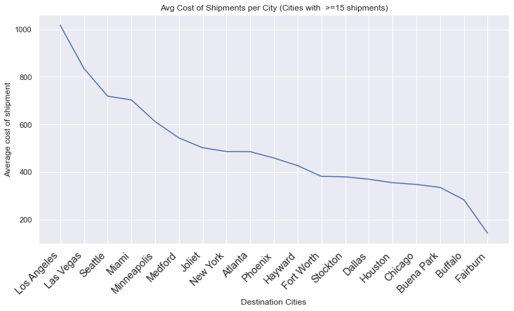

```python
#Visual for Question 4

sql = '''
SELECT shipper_id, Dest_City, Dest_State, Dest_Country, AVG(cost)
FROM shipments
WHERE Dest_Country = 'US'
GROUP BY Dest_City, Dest_State
HAVING COUNT(shipper_id) >= 15
ORDER BY AVG(cost) DESC
'''

## Execute the SQL Statement
cursor.execute(sql)

## Run the query over the connection instead of using the cursor
df = pd.read_sql_query(sql, conn)

# Verify that result of SQL query is stored in the dataframe
#print(df)

sns.set(style="darkgrid")
plt.figure(figsize=(12,6))
sns.lineplot(x='Dest_City', y='AVG(cost)', data=df)

plt.xlabel("Destination Cities")
plt.ylabel("Average cost of shipment")
plt.title("Avg Cost of Shipments per City (Cities with  >=15 shipments)")
plt.xticks(
    rotation=45,
    horizontalalignment='right',
    fontweight='light',
    fontsize='large'
)
```

```python
## Question 5
#How do cities vary in shipment weight on average? Order results in descending order. Only include cities with 15 or more shipments.
sql = '''
SELECT shipper_id, Dest_City, Dest_State, Dest_Country, AVG(Total_Weight)
FROM shipments
WHERE Dest_Country = 'US' AND Total_Weight < 100000
GROUP BY Dest_City, Dest_State
HAVING COUNT(shipper_id) >= 15
ORDER BY AVG(Total_Weight) DESC

'''

## Execute the SQL Statement
cursor.execute(sql)

## Print the result
for row in cursor.fetchall():
  print(row[0], row[1:10])
```

```
14454 ('Medford', 'OR', 'US', 3647.8947368421054)
21684 ('Stockton', 'CA', 'US', 2295.5)
20765 ('Seattle', 'WA', 'US', 1833.34375)
18063 ('Los Angeles', 'CA', 'US', 1725.0588235294117)
22393 ('Las Vegas', 'NV', 'US', 1706.3125)
16469 ('Minneapolis', 'MN', 'US', 1481.2)
18807 ('Hayward', 'CA', 'US', 1428.9130434782608)
18199 ('Atlanta', 'GA', 'US', 1378.8125)
18199 ('Buffalo', 'NY', 'US', 1223.8666666666666)
22233 ('Houston', 'TX', 'US', 1120.3333333333333)
15606 ('Fort Worth', 'TX', 'US', 1042.625)
17727 ('Miami', 'FL', 'US', 944.9268292682926)
22393 ('Dallas', 'TX', 'US', 890.9375)
15462 ('Phoenix', 'AZ', 'US', 862.0)
19334 ('Joliet', 'IL', 'US', 746.1612903225806)
8240 ('Buena Park', 'CA', 'US', 679.4137931034483)
15462 ('Chicago', 'IL', 'US', 651.2666666666667)
1734 ('New York', 'NY', 'US', 510.94444444444446)
18568 ('Fairburn', 'GA', 'US', 306.8181818181818)
```

[output not shown]

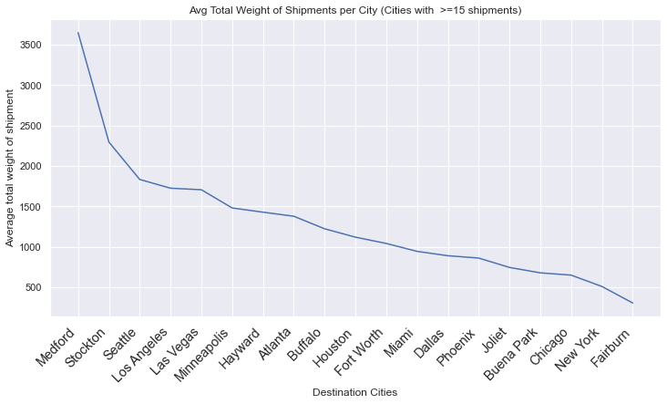

```python
#Visual for Question 5

sql = '''
SELECT shipper_id, Dest_City, Dest_State, Dest_Country, AVG(Total_Weight)
FROM shipments
WHERE Dest_Country = 'US' AND Total_Weight < 100000
GROUP BY Dest_City, Dest_State
HAVING COUNT(shipper_id) >= 15
ORDER BY AVG(Total_Weight) DESC

'''

## Execute the SQL Statement
cursor.execute(sql)

## Run the query over the connection instead of using the cursor
df = pd.read_sql_query(sql, conn)

# Verify that result of SQL query is stored in the dataframe
#print(df)

sns.set(style="darkgrid")
plt.figure(figsize=(12,6))
sns.lineplot(x='Dest_City', y='AVG(Total_Weight)', data=df)

plt.xlabel("Destination Cities")
plt.ylabel("Average total weight of shipment")
plt.title("Avg Total Weight of Shipments per City (Cities with  >=15 shipments)")
plt.xticks(
    rotation=45,
    horizontalalignment='right',
    fontweight='light',
    fontsize='large'
)
```

```python
## Question 6
#is there a correlation between the total cost and total weight of shipments per city/state when looking at the maximum values?
sql = '''
SELECT shipper_id, Dest_City, Dest_State, Dest_Country, MAX(Total_Weight), MAX(cost)
FROM shipments
WHERE Dest_Country = 'US' AND Total_Weight < 100000
GROUP BY Dest_City, Dest_State

'''

## Execute the SQL Statement
cursor.execute(sql)

## Print the result
for row in cursor.fetchall():
  print(row[0], row[1:10])
```

```
15443 ('Aberdeen', 'NC', 'US', 520, 673.26)
23148 ('Aberdeen', 'WA', 'US', 1797, 799.04)
7833 ('Adair', 'OK', 'US', 1000, 773.06)
15217 ('Adairsville', 'GA', 'US', 250, 402.05)
18194 ('Akron', 'OH', 'US', 12000, 8200.0)
15657 ('Alameda', 'CA', 'US', 105, 344.61)
21583 ('Albany', 'NY', 'US', 639, 257.18)
11788 ('Albany', 'OR', 'US', 15000, 4000.0)
18097 ('Albert Lea', 'MN', 'US', 15750, 1827.48)
5771 ('Alcoa', 'TN', 'US', 155, 250.31)
21271 ('Alexandria', 'VA', 'US', 6000, 1945.98)
23519 ('Alexandria Bay', 'NY', 'US', 1050, 736.48)
20808 ('Allegany', 'NY', 'US', 900, 460.0)
9427 ('Allentown', 'PA', 'US', 2460, 412.07)
18877 ('Allenwood', 'NJ', 'US', 2000, 440.3)
```

[output cut: 1195 more lines]

[output not shown]

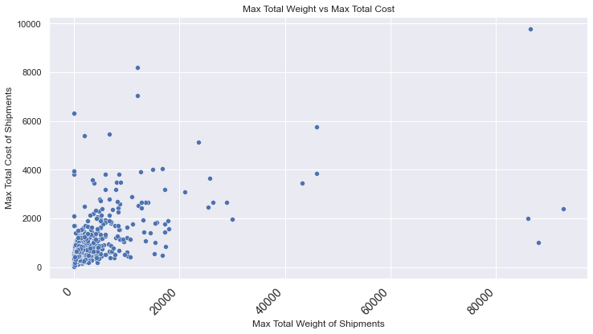

```python
#Visual for Question 6

sql = '''
SELECT shipper_id, Dest_City, Dest_State, Dest_Country, MAX(Total_Weight), MAX(cost)
FROM shipments
WHERE Dest_Country = 'US' AND Total_Weight < 100000
GROUP BY Dest_City, Dest_State

'''

## Execute the SQL Statement
cursor.execute(sql)

## Run the query over the connection instead of using the cursor
df = pd.read_sql_query(sql, conn)

# Verify that result of SQL query is stored in the dataframe
#print(df)

sns.set(style="darkgrid")
plt.figure(figsize=(12,6))
sns.scatterplot(x='MAX(Total_Weight)', y='MAX(cost)', data=df)

plt.xlabel("Max Total Weight of Shipments")
plt.ylabel("Max Total Cost of Shipments")
plt.title("Max Total Weight vs Max Total Cost")
plt.xticks(
    rotation=45,
    horizontalalignment='right',
    fontweight='light',
    fontsize='large'
)

#there does not appear to be an obvious correlation from the scatterplot.
```

```python
#correlation coefficient for Question 6

sql = '''
SELECT shipper_id, Dest_City, Dest_State, Dest_Country, MAX(Total_Weight), MAX(cost)
FROM shipments
WHERE Dest_Country = 'US' AND Total_Weight < 100000
GROUP BY Dest_City, Dest_State

'''

## Execute the SQL Statement
cursor.execute(sql)

## Run the query over the connection instead of using the cursor
df = pd.read_sql_query(sql, conn)

# Verify that result of SQL query is stored in the dataframe
#print(df)

stats.spearmanr(df['MAX(Total_Weight)'], df['MAX(cost)'])


#We are using a spearman correlation function because it captures monotonic relationships better and doesn't require the normality assumption of pearson correlation function.
#We probably could still use pearson correlation function but it would require us to log transform the data

#From the results of the spearman correlation function, we have a pretty moderate to strong correlation between total weight and total cost of shipment when looking at
#the maximum values per city/state
```

```
SpearmanrResult(correlation=0.6237360594997711, pvalue=2.0611382109326812e-131)
```

```python
## Question 7
#4.	How many shippers booked freight in each month for each combination of pickup/destination country?
sql = '''
SELECT COUNT(shipper_id), strftime('%Y-%m', Pickup_Date) as Year_Month, PickUp_Country, Dest_Country
FROM shipments
WHERE Year_Month IS NOT Null
GROUP BY Year_Month, PickUp_Country, Dest_Country

'''

## Execute the SQL Statement
cursor.execute(sql)

## Print the result
for row in cursor.fetchall():
  print(row[0], row[1:10])
```

```
2 ('2020-12', 'US', 'US')
543 ('2021-01', 'CA', 'CA')
112 ('2021-01', 'CA', 'US')
142 ('2021-01', 'US', 'CA')
219 ('2021-01', 'US', 'US')
574 ('2021-02', 'CA', 'CA')
107 ('2021-02', 'CA', 'US')
145 ('2021-02', 'US', 'CA')
160 ('2021-02', 'US', 'US')
751 ('2021-03', 'CA', 'CA')
184 ('2021-03', 'CA', 'US')
173 ('2021-03', 'US', 'CA')
272 ('2021-03', 'US', 'US')
768 ('2021-04', 'CA', 'CA')
182 ('2021-04', 'CA', 'US')
190 ('2021-04', 'US', 'CA')
252 ('2021-04', 'US', 'US')
642 ('2021-05', 'CA', 'CA')
140 ('2021-05', 'CA', 'US')
159 ('2021-05', 'US', 'CA')
224 ('2021-05', 'US', 'US')
682 ('2021-06', 'CA', 'CA')
166 ('2021-06', 'CA', 'US')
204 ('2021-06', 'US', 'CA')
324 ('2021-06', 'US', 'US')
468 ('2021-07', 'CA', 'CA')
107 ('2021-07', 'CA', 'US')
1 ('2021-07', 'DK', 'CA')
156 ('2021-07', 'US', 'CA')
199 ('2021-07', 'US', 'US')
```

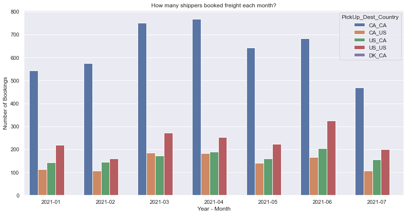

```python
#Visual for Question 7

sql = '''
SELECT COUNT(shipper_id), strftime('%Y-%m', Pickup_Date) as Year_Month, PickUp_Country, Dest_Country
FROM shipments
WHERE Year_Month IS NOT Null
GROUP BY Year_Month, PickUp_Country, Dest_Country

'''

## Execute the SQL Statement
cursor.execute(sql)

## Run the query over the connection instead of using the cursor
df = pd.read_sql_query(sql, conn)

# Verify that result of SQL query is stored in the dataframe
#print(df)

df['PickUp_Dest_Country'] = df['PickUp_Country'] +'_'+ df['Dest_Country']
#print(df)

#2020-12 did not have much data (only 2 bookings) so let's take it out

df[['Year','Month']] = df.Year_Month.str.split("-",expand=True)
df_new = df.loc[df.loc[:,"Year"] != '2020',:]
#print(df_new)

plt.figure(figsize=(14,7))
sns.barplot(x="Year_Month",y="COUNT(shipper_id)",hue="PickUp_Dest_Country", data=df_new)

plt.xlabel("Year - Month")
plt.ylabel("Number of Bookings")
plt.title("How many shippers booked freight each month?")
```

```python
## Question 8
#How many shippers booked freight at least 50 times?
# What are the home countries of these big shippers?
sql = '''

SELECT shipper_id, shippers.country, COUNT(shipper_id)
FROM shipments NATURAL JOIN shippers
GROUP BY shipper_id
HAVING COUNT(shipper_id) >= 50

'''

## Execute the SQL Statement
cursor.execute(sql)

## Print the result
print("(Shipper ID, Shipper's Country, Number of Bookings)")
for row in cursor.fetchall():
  print(row[0:10])
```

```
(Shipper ID, Shipper's Country, Number of Bookings)
(1098, 'CA', 82)
(1734, 'CA', 54)
(4562, 'CA', 83)
(6108, 'CA', 52)
(6944, 'CA', 77)
(8008, 'CA', 150)
(10564, 'CA', 76)
(11577, 'CA', 64)
(13421, 'CA', 74)
(14012, 'CA', 128)
(14454, 'US', 98)
(15462, 'US', 83)
(15553, 'CA', 61)
(18142, 'CA', 182)
(18199, 'US', 87)
(18278, 'CN', 71)
(18568, 'US', 50)
(18807, 'US', 69)
(20446, 'CA', 152)
(21583, 'CA', 54)
(21941, 'CA', 59)
(22508, 'CA', 62)
(22824, 'CA', 118)
(22907, 'CA', 55)
```

```python
## Question 9
## What's the conversion rate for each month in Quarter 2?  In other words, what % of quotes result in shipments, grouped by month?

q6_sql = '''

SELECT
    Month,
    round((Shipments*100.00/Quotes),2) as 'Conversion Rate %'
FROM

  (SELECT
         Month,
         SUM(CASE WHEN Transact = 'Quote' THEN Items ELSE 0 END) AS Quotes,
         SUM(CASE WHEN Transact = 'Shipment' THEN Items ELSE 0 END) AS Shipments,
         SUM(Items) AS Total
  FROM

    (SELECT
        'Quote' as Transact,
        printf('%02d', Month) Month,
        cast(round(Month/3.0 + 0.495) as int) as Quarter,
        count(*) as Items
      FROM quotes
      WHERE Month != "" AND Quarter = 2
      GROUP BY Transact, Month

    UNION ALL

    SELECT
        'Shipment' as Transact,
        strftime('%m', Pickup_Date) as Month,
        cast(round(strftime ('%m', Pickup_Date)/3.0 + 0.495) as int) as Quarter,
        count(*) as Items
      FROM shipments
      WHERE Quarter = 2
      GROUP BY Transact, Month) as totals

  GROUP BY Month)
'''

## Run the query over the connection instead of using the cursor
q6_df = pd.read_sql_query(q6_sql, conn)

# Verify that result of SQL query is stored in the dataframe
print(q6_df)
```

```
  Month  Conversion Rate %
0    04              39.76
1    05              37.73
2    06              46.25
```

```python
## Question 10
## After applying the discount schedule to the total set of shipments each shipper made,
## provide a sum total of discounts that each shipper would have received,
## had they benefited from the discounts

q7_sql = '''
SELECT shipper_id,
  sum(cost) AS total_cost,
  count(Load_Id) AS loads,
  sum(CASE
	  WHEN cost < 100 THEN 0
  	WHEN cost < 300 THEN 10
    WHEN cost < 500 THEN 20
    WHEN cost < 1000 THEN 35
  	ELSE 50
  END) AS total_discount
FROM
	shipments
GROUP BY shipper_id
;
'''

q7_df = pd.read_sql_query(q7_sql, conn)

# Verify that result of SQL query is stored in the dataframe
print(q7_df)
```

```
      shipper_id  total_cost  loads  total_discount
0             23    17058.55     12             320
1            174       85.38      1               0
2            372     3035.00      8             175
3            440      730.00      2              30
4            812      252.10      1              10
...          ...         ...    ...             ...
1335       25176     1166.35      1              50
1336       25184      775.00      1              35
1337       25188      593.05      1              35
1338       25189      485.07      1              20
1339       25213       79.99      1               0

[1340 rows x 4 columns]
```

```python
## Close the Cursor
cursor.close()
```